```python
# Author: Arthur Prigent
# Email: arthur.prigent@univ-brest.fr

#### DATA ####
# https://downloads.psl.noaa.gov/Datasets/
from functions import *
import warnings
warnings.filterwarnings("ignore")
from IPython.display import Image
```

```
2026-08-31 18:33:08.534652
```

# SST anomalies timeseries

# Monthly timeseries

# Zonal wind anomalies timeseries

# Monthly timeseries

# WAMOI

## West African Monsoon Onset

# ACT

## Atlantic Cold Tongue Onset

# AMM

## Atlantic Meridional mode index

# AMO

## Atlantic Multi-decadal Oscillation

# St Helena SLP index

## SLP index

# Identification of Atlantic Niños/Niños and Benguela Niños/Niñas

# PIRATA data

# Temperature PIRATA 23˚W, 10˚W, 0˚E

# Canonical/Non-canonical Atlantic Niños

# Indian Ocean Dipole

# Seasonal forecast CFSv2

# References

# link

# Regions of interests

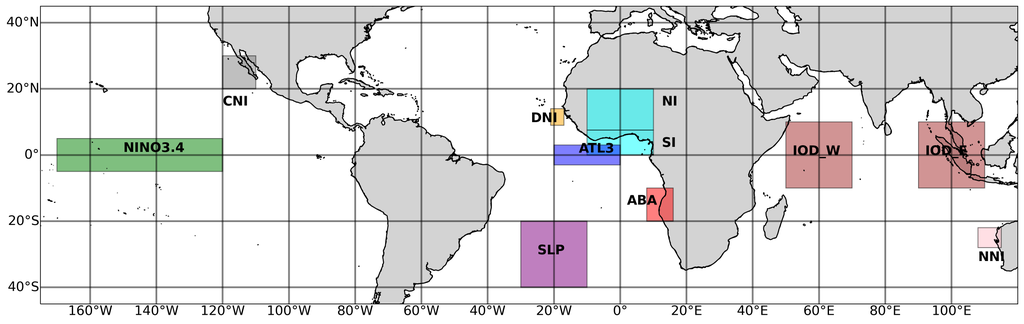

```python
Image(filename='fig_boxes_map.png')
```

# Last update

```python
print(str(now)[:16])
```

```
2026-08-31 18:33
```

# Read SST data

```python
path_data = 'http://psl.noaa.gov/thredds/dodsC/Datasets/COBE2/sst.mon.mean.nc'
(ssta_atl3_norm_cobe,ssta_aba_norm_cobe,
 ssta_nino34_norm_cobe,ssta_dni_norm_cobe,
 ssta_cni_norm_cobe,ssta_nni_norm_cobe,iod_cobe) = read_data_compute_anomalies(path_data)
```

```python
#path_oi = 'https://psl.noaa.gov/thredds/dodsC/Datasets/noaa.oisst.v2/'
#path_oi = 'http://psl.noaa.gov/thredds/dodsC/Datasets/noaa.oisst.v2.highres/'
#(ssta_atl3_norm_oi,ssta_aba_norm_oi,
# ssta_nino34_norm_oi,ssta_dni_norm_oi,
# ssta_cni_norm_oi,ssta_nni_norm_oi,iod_index) = read_data_compute_anomalies_oi(path_oi)
```

```python
path_ersstv5 = 'https://psl.noaa.gov/thredds/dodsC/Datasets/noaa.ersst.v5/sst.mnmean.nc'
(ssta_atl3_norm_ersst,ssta_aba_norm_ersst,
 ssta_nino34_norm_ersst,ssta_dni_norm_ersst,
 ssta_cni_norm_ersst,ssta_nni_norm_ersst,iod_ersst) = read_data_compute_anomalies_ersstv5(path_ersstv5)
```

# Timeseries of SST anomalies

# Monthly data

# [COBE SST](https://psl.noaa.gov/data/gridded/data.cobe.html) | 1$^{\circ}$ x 1$^{\circ}$ | Monthly

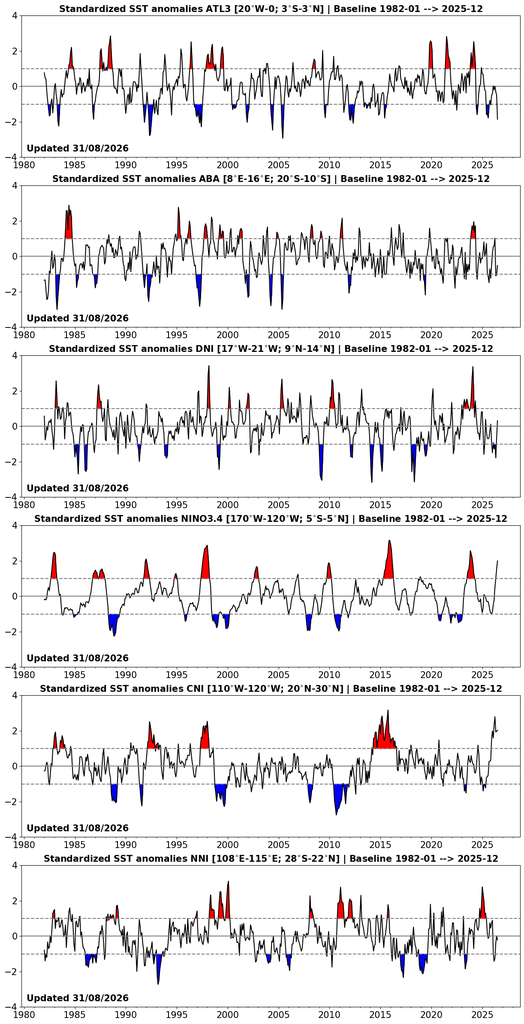

```python
plot_anomalies(ssta_atl3_norm_cobe,
               ssta_aba_norm_cobe,
               ssta_nino34_norm_cobe,
               ssta_dni_norm_cobe,
               ssta_cni_norm_cobe,
               ssta_nni_norm_cobe)
```

# [OI SST v2](https://psl.noaa.gov/data/gridded/data.noaa.oisst.v2.html) | 1$^{\circ}$ x 1$^{\circ}$ | Monthly

```python
#plot_anomalies(ssta_atl3_norm_oi,
#               ssta_aba_norm_oi,
#               ssta_nino34_norm_oi,
#               ssta_dni_norm_oi,
#               ssta_cni_norm_oi,
#               ssta_nni_norm_oi)
```

# [ERSST V5](https://psl.noaa.gov/data/gridded/data.noaa.ersst.v5.html) | 2$^{\circ}$ x 2$^{\circ}$ | Monthly

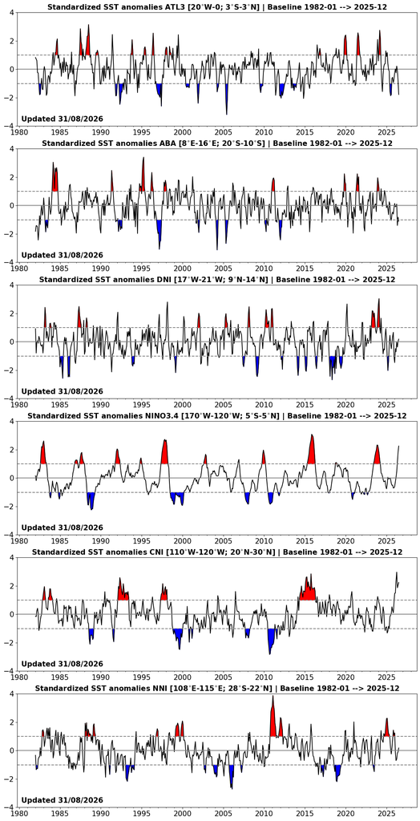

```python
plot_anomalies(ssta_atl3_norm_ersst,
               ssta_aba_norm_ersst,
               ssta_nino34_norm_ersst,
               ssta_dni_norm_ersst,
               ssta_cni_norm_ersst,
               ssta_nni_norm_ersst)
```

# ATL4 zonal wind

# [NCEP-V1](https://psl.noaa.gov/data/gridded/data.ncep.reanalysis.html) | 2 x 2 | Monthly

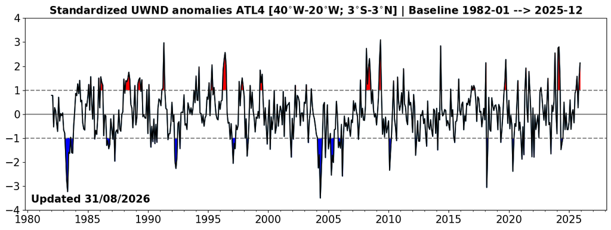

```python
ncep_data = 'https://psl.noaa.gov/thredds/dodsC/Datasets/ncep.reanalysis/Monthlies/surface/uwnd.mon.mean.nc'
uwnda_atl4_norm = read_compute_anomalies_uwind_plot(ncep_data)
```

# WAMOI: West African Monsoon onset index from 2000 to present day

Methodology inspired from : Fontaine and Louvet (2006)

# WAMOI = NI$_{std}$ - SI$_{std}$

- with NI being the precipitation averaged over 7.5$^\circ$N-20$^\circ$N; 10$^\circ$W-10$^\circ$E
- and with SI the precipitation averaged over 0$^\circ$N-7.5$^\circ$N; 10$^\circ$W-10$^\circ$E

  --> NI and SI are then standardized i.e. NI$_{std}$ = NI/(std(NI))

  --> a 5-pentad running mean is then apply to the WAMOI time series

# [CPC Merged Analysis of Precipitation](https://psl.noaa.gov/data/gridded/data.cmap.html) | 2.5$^{\circ}$ x 2.5$^{\circ}$ | Weekly

```
(27, 73)
```

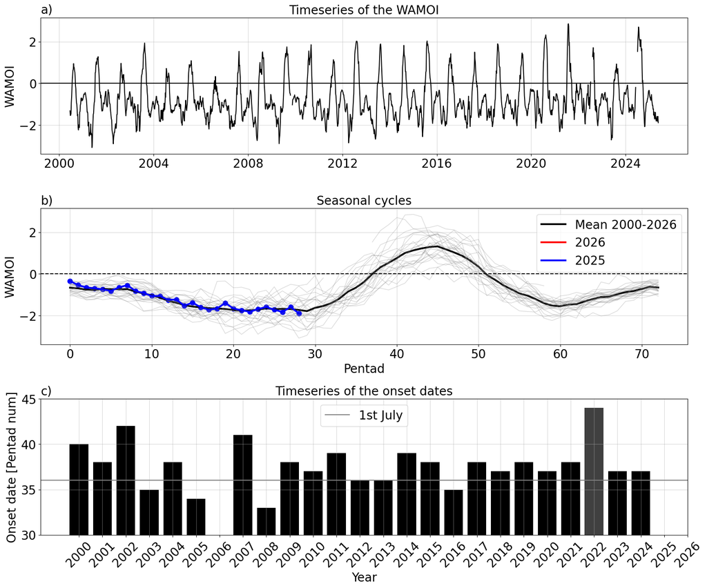

```python
path_cmap = 'http://psl.noaa.gov/thredds/dodsC/Datasets/cmap/rt/precip.pentad.mean.rt.nc'
plot_wamoi(path_cmap)
```

# Atlantic Cold Tongue Onset | Caniaux et al., (2011) | Weekly

Sact = $\int_{A(x)} He(25^{\circ}C-SST(x))dA$

where He is the Heaviside function (He = 1 when SST < 25$^{\circ}$C and 0 otherwise). The SST index expresses the intensity of the cooling in the ACT and is defined point by point by subtracting the SST for each grid point from a SST of 25$^{\circ}$C (so that SSTs below 25$^{\circ}$C imply a positive index) inside the domain A, 30$^{\circ}$W–12$^{\circ}$E and 5$^{\circ}$S–5$^{\circ}$N.

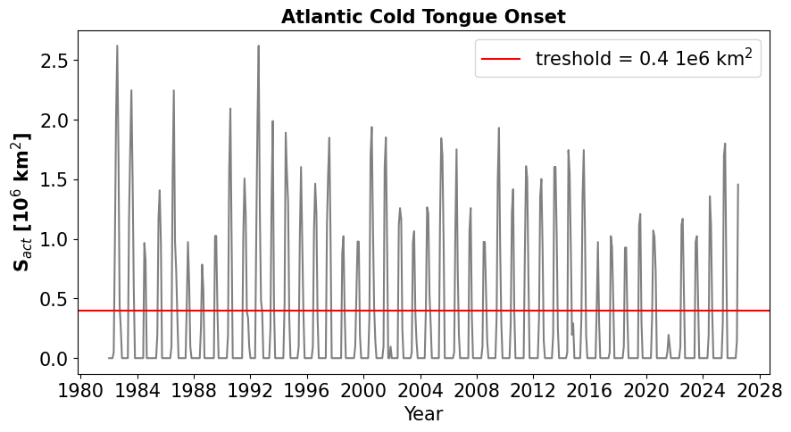

```python
path_ersstv5 = 'https://psl.noaa.gov/thredds/dodsC/Datasets/noaa.ersst.v5/'
sst = read_data_ACT_week_plot_ersstv5(path_ersstv5)
```

# [Atlantic Meridional mode](https://www.aos.wisc.edu/~dvimont/MModes/AMM.html) | Chiang and Vimont (2004) | Monthly

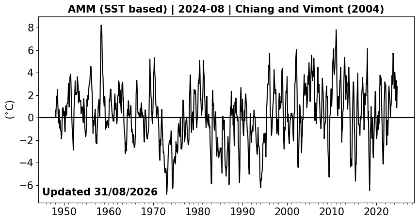

```python
data_amm = 'https://psl.noaa.gov/data/timeseries/monthly/AMM/ammsst.data'
amm_plot_new(data_amm)
```

# [Atlantic Multi-decadal Oscillation](https://psl.noaa.gov/data/timeseries/AMO/) | Monthly

```python
#data_amo= 'https://www1.ncdc.noaa.gov/pub/data/cmb/ersst/v5/index/ersst.v5.amo.dat'
#plot_amo_new(data_amo)
```

# [St Helena index](https://psl.noaa.gov/data/gridded/data.ncep.reanalysis.derived.html) (SLP based 3-month running mean) | Monthly

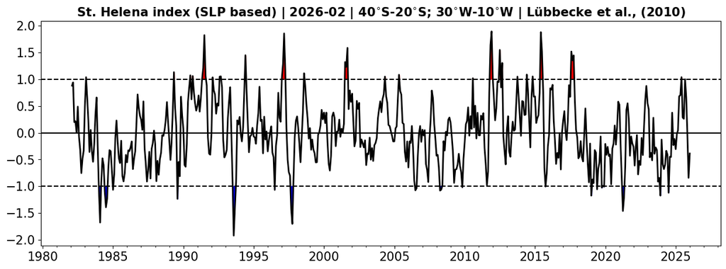

```python
ncep_data_slp = 'https://psl.noaa.gov/thredds/dodsC/Datasets/ncep.reanalysis.derived/surface/slp.mon.mean.nc'
plot_slp(ncep_data_slp)
```

# Indian Ocean Dipole index

### COBE-SST

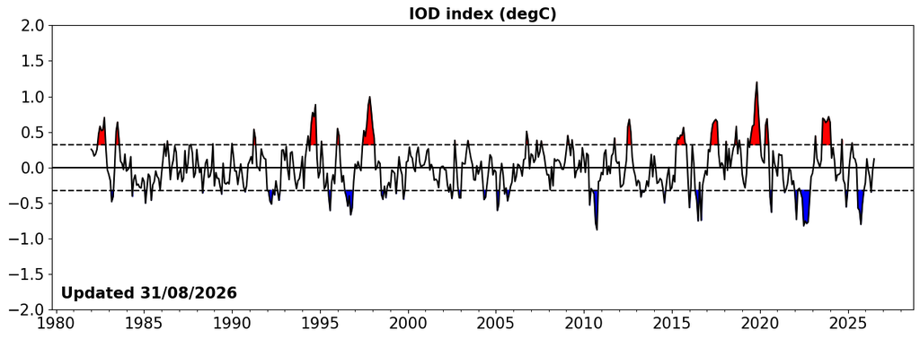

```python
plot_IOD(iod_cobe)
```

### ERSST v5

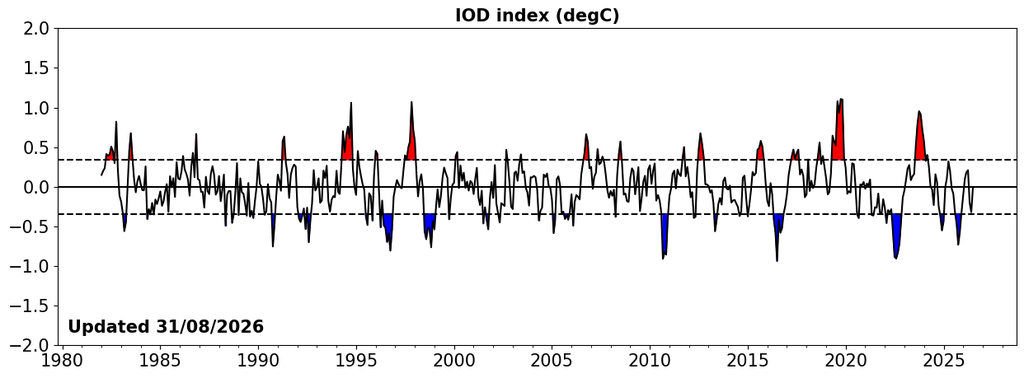

```python
plot_IOD(iod_ersst)
```

# Identification of Atlantic Niños/Niños and Benguela Niños/Niñas

### Atlantic Niño events since 1982

```python
_,_,table_atl3_w,table_atl3_c = create_table_event_new(ssta_atl3_norm_ersst)
table_atl3_w
```

|  | Start date | End date | Duration | Mean SSTa | Cumul SSTa | Max SSTa | Date max SSTa |
| --- | --- | --- | --- | --- | --- | --- | --- |
| 0 | 1984-06 | 1984-10 | 4 | 1.61 | 6.44 | 2.14 | 1984-09 |
| 1 | 1987-06 | 1987-10 | 4 | 1.98 | 7.93 | 2.86 | 1987-07 |
| 2 | 1988-03 | 1988-09 | 6 | 2.17 | 13.02 | 3.15 | 1988-07 |
| 3 | 1989-06 | 1989-10 | 4 | 1.20 | 4.82 | 1.34 | 1989-08 |
| 4 | 1993-09 | 1994-01 | 4 | 1.41 | 5.64 | 2.09 | 1993-11 |
| 5 | 1995-05 | 1995-08 | 3 | 1.46 | 4.38 | 1.58 | 1995-06 |
| 6 | 1996-05 | 1996-08 | 3 | 1.79 | 5.36 | 2.55 | 1996-06 |
| 7 | 1997-12 | 1998-03 | 3 | 1.47 | 4.42 | 1.56 | 1998-01 |
| 8 | 1998-06 | 1998-09 | 3 | 1.33 | 3.99 | 1.62 | 1998-06 |
| 9 | 2016-10 | 2017-01 | 3 | 1.25 | 3.75 | 1.47 | 2016-11 |
| 10 | 2019-11 | 2020-03 | 4 | 2.16 | 8.65 | 2.41 | 2020-01 |
| 11 | 2021-06 | 2021-10 | 4 | 2.11 | 8.46 | 2.57 | 2021-07 |
| 12 | 2024-02 | 2024-05 | 3 | 2.15 | 6.46 | 2.75 | 2024-03 |

### Atlantic Niña events since 1982

```python
table_atl3_c
```

|  | Start date | End date | Duration | Mean SSTa | Cumul SSTa | Max SSTa | Date max SSTa |
| --- | --- | --- | --- | --- | --- | --- | --- |
| 0 | 1982-06 | 1982-10 | 4 | -1.41 | -5.66 | -1.79 | 1982-07 |
| 1 | 1991-11 | 1992-02 | 3 | -1.62 | -4.86 | -1.87 | 1991-11 |
| 2 | 1992-04 | 1992-10 | 6 | -1.73 | -10.40 | -2.47 | 1992-05 |
| 3 | 1996-11 | 1997-07 | 8 | -1.73 | -13.88 | -2.59 | 1997-06 |
| 4 | 2000-06 | 2000-12 | 6 | -1.23 | -7.36 | -1.28 | 2000-11 |
| 5 | 2001-11 | 2002-02 | 3 | -1.87 | -5.60 | -2.39 | 2001-12 |
| 6 | 2004-04 | 2004-07 | 3 | -1.37 | -4.11 | -1.59 | 2004-04 |
| 7 | 2005-05 | 2005-08 | 3 | -2.55 | -7.64 | -3.19 | 2005-06 |
| 8 | 2009-07 | 2009-12 | 5 | -1.30 | -6.51 | -1.64 | 2009-08 |
| 9 | 2011-12 | 2012-08 | 8 | -1.65 | -13.18 | -2.03 | 2012-02 |
| 10 | 2013-07 | 2014-01 | 6 | -1.25 | -7.49 | -1.50 | 2013-09 |
| 11 | 2025-06 | 2025-09 | 3 | -1.73 | -5.20 | -1.86 | 2025-07 |

### Benguela Niño events since 1982

```python
_,_,table_aba_w,table_aba_c = create_table_event_new(ssta_aba_norm_ersst)
table_aba_w
```

|  | Start date | End date | Duration | Mean SSTa | Cumul SSTa | Max SSTa | Date max SSTa |
| --- | --- | --- | --- | --- | --- | --- | --- |
| 0 | 1984-02 | 1984-10 | 8 | 2.32 | 18.52 | 3.05 | 1984-03 |
| 1 | 1991-05 | 1991-08 | 3 | 1.78 | 5.34 | 2.47 | 1991-05 |
| 2 | 1994-10 | 1995-01 | 3 | 1.40 | 4.19 | 1.54 | 1994-10 |
| 3 | 1995-02 | 1995-06 | 4 | 2.60 | 10.39 | 3.41 | 1995-04 |
| 4 | 1996-03 | 1996-07 | 4 | 1.61 | 6.45 | 2.33 | 1996-04 |
| 5 | 1997-10 | 1998-02 | 4 | 1.57 | 6.27 | 1.77 | 1997-12 |
| 6 | 2011-01 | 2011-05 | 4 | 1.79 | 7.16 | 1.95 | 2011-03 |
| 7 | 2019-11 | 2020-02 | 3 | 1.80 | 5.39 | 2.24 | 2019-11 |
| 8 | 2021-05 | 2021-09 | 4 | 1.82 | 7.27 | 2.23 | 2021-06 |
| 9 | 2023-11 | 2024-03 | 4 | 1.42 | 5.70 | 1.96 | 2023-12 |

### Benguela Niña events since 1982

```python
table_aba_c
```

|  | Start date | End date | Duration | Mean SSTa | Cumul SSTa | Max SSTa | Date max SSTa |
| --- | --- | --- | --- | --- | --- | --- | --- |
| 0 | 1983-03 | 1983-08 | 5 | -1.42 | -7.11 | -1.86 | 1983-04 |
| 1 | 1991-11 | 1992-02 | 3 | -1.08 | -3.25 | -1.14 | 1991-11 |
| 2 | 1992-03 | 1992-09 | 6 | -1.52 | -9.11 | -1.82 | 1992-03 |
| 3 | 1996-11 | 1997-07 | 8 | -2.00 | -15.97 | -3.08 | 1997-03 |
| 4 | 2001-12 | 2002-03 | 3 | -1.43 | -4.29 | -1.90 | 2002-01 |
| 5 | 2004-03 | 2004-06 | 3 | -2.27 | -6.82 | -3.13 | 2004-04 |
| 6 | 2005-04 | 2005-09 | 5 | -1.68 | -8.39 | -2.67 | 2005-05 |
| 7 | 2010-02 | 2010-05 | 3 | -1.48 | -4.45 | -1.84 | 2010-04 |
| 8 | 2011-06 | 2011-09 | 3 | -1.12 | -3.35 | -1.18 | 2011-08 |
| 9 | 2011-11 | 2012-04 | 5 | -1.76 | -8.78 | -2.42 | 2012-01 |

# Canonical/Non-canonical Atlantic Niños

Figure inspired by the Richter et al., (2013), in which they identify some warm events that can not be explained by previously identify equatorial wind stress forcing.

--> A warm SST event is categorized as a canonical (non-canonical) event when it is preceded by a positive (negative) surface wind anomaly. Hence, canonical events lie in the upper right (in red) and lower left (in blue), and non-canonical events lie in the upper left and lower right (in black) quadrants.

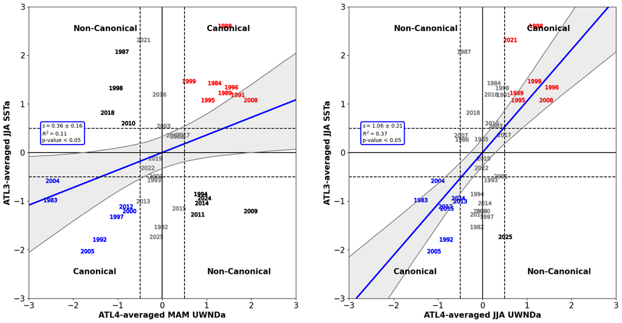

```python
plot_canonical_atlantic_ninos(uwnda_atl4_norm,ssta_atl3_norm_ersst)
```

# [Forecast from CFSv2 next three month](https://www.cpc.ncep.noaa.gov/products/CFSv2/CFSv2_body.html)

# +1 month

```python
Image(url='https://www.cpc.ncep.noaa.gov/products/CFSv2/imagesInd3/glbSSTMonInd2.gif')
```

[figure not shown]

# +2 month

```python
Image(url='https://www.cpc.ncep.noaa.gov/products/CFSv2/imagesInd3/glbSSTMonInd3.gif')
```

[figure not shown]

# +3 Month

```python
Image(url='https://www.cpc.ncep.noaa.gov/products/CFSv2/imagesInd3/glbSSTMonInd4.gif')
```

[figure not shown]

# Last days SST anomalies

```python
Image(url='https://climatereanalyzer.org/wx/todays-weather/maps/gfs_world-wt_sstanom_d1.png')
```

[figure not shown]

# Last days SST

```python
Image(url='https://climatereanalyzer.org/wx/todays-weather/maps/gfs_world-wt_sst_d1.png')
```

[figure not shown]

# [Animations from the CPC](https://www.cpc.ncep.noaa.gov/products/GODAS/background.shtml)

# [Subsurface temperature anomalies](https://www.cpc.ncep.noaa.gov/products/GODAS/)

```python
Image(url='https://www.cpc.ncep.noaa.gov/products/GODAS/pent_gif/xz/movie.temp.0n.gif',width=800)
```

[figure not shown]

# [Z20 anomalies](https://www.cpc.ncep.noaa.gov/products/GODAS/)

```python
Image(url='https://www.cpc.ncep.noaa.gov/products/GODAS/pent_gif/xy/movie.d20.gif',width=800)
```

[figure not shown]

# References

- Caniaux, G., H. Giordani, J.‐L. Redelsperger, F. Guichard, E. Key, and M. Wade (2011), Coupling between the Atlantic cold tongue and the West African monsoon in boreal spring and summer, J. Geophys. Res., 116, C04003, doi:10.1029/2010JC006570.
- Chiang, J. C. H., & Vimont, D. J. (2004). Analogous Pacific and Atlantic Meridional Modes of Tropical Atmosphere–Ocean Variability, Journal of Climate, 17(21), 4143-4158.
- Enfield, D.B., A.M. Mestas-Nunez, and P.J. Trimble, 2001: The Atlantic Multidecadal Oscillation and its relationship to rainfall and river flows in the continental U.S., Geophys. Res. Lett., 28: 2077-2080.
- Fontaine, B., and S. Louvet (2006), Sudan-Sahel rainfall onset: Definition of an objective index, types of years, and experimental hindcasts, J. Geophys. Res., 111, D20103, doi:10.1029/2005JD007019.
- Richter, I., Behera, S., Masumoto, Y. et al. Multiple causes of interannual sea surface temperature variability in the equatorial Atlantic Ocean. Nature Geosci 6, 43–47 (2013). https://doi.org/10.1038/ngeo1660